# Anomaly detector based on PHAD-C32 (1999)

### Detection by attack filtered by category

On this graph, we can see the detection by attack and for specific category. Also we show a table with the Top scored attacks detected (attacks with 0 scored has been removed).

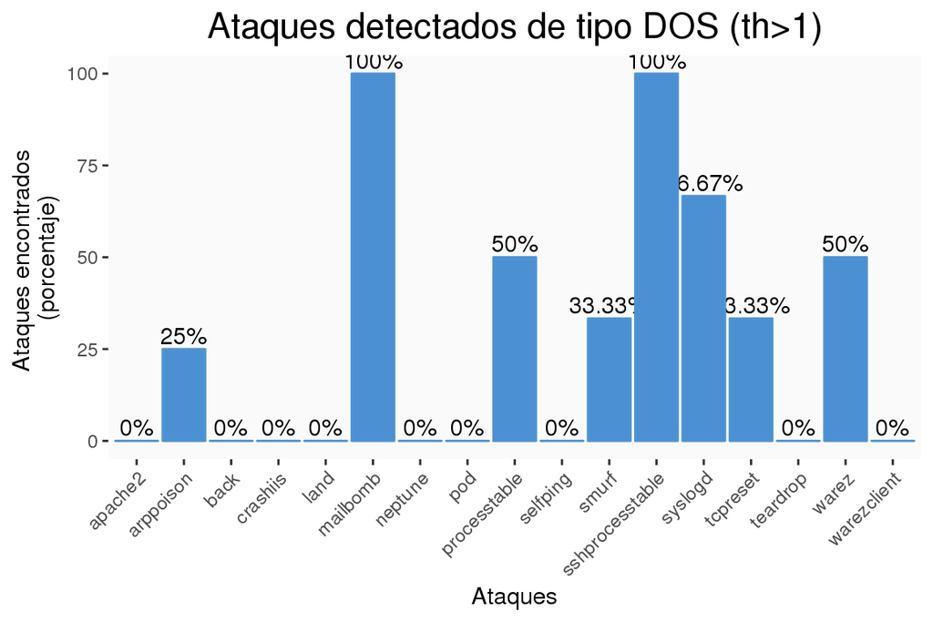

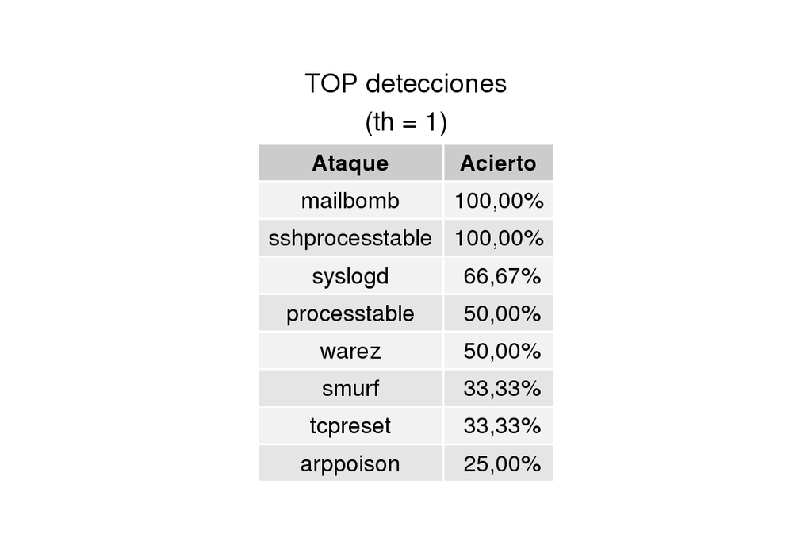

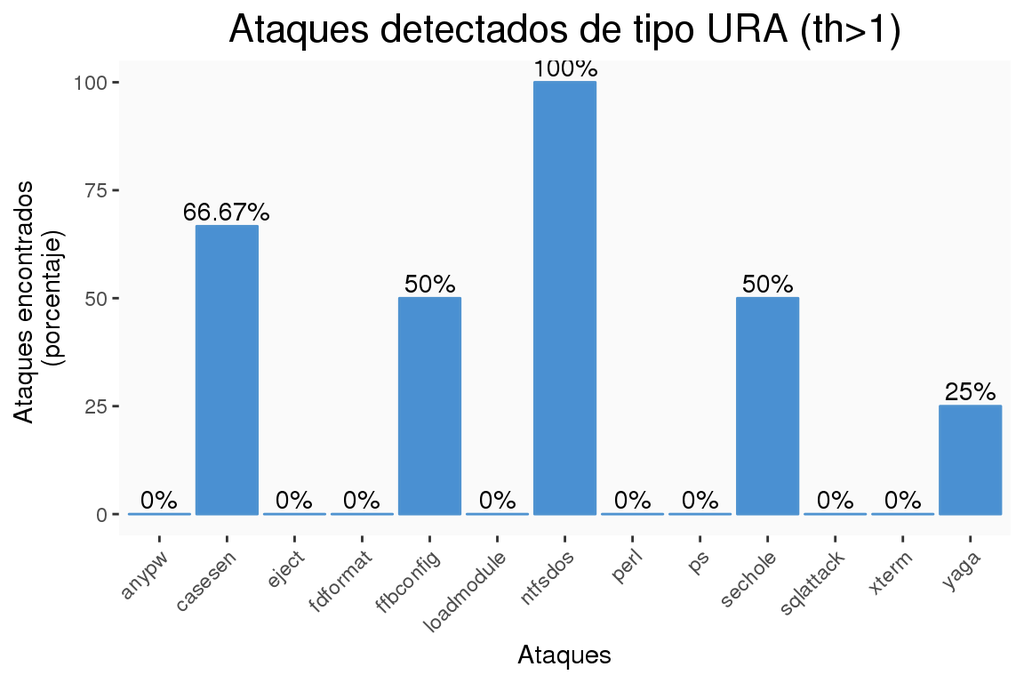

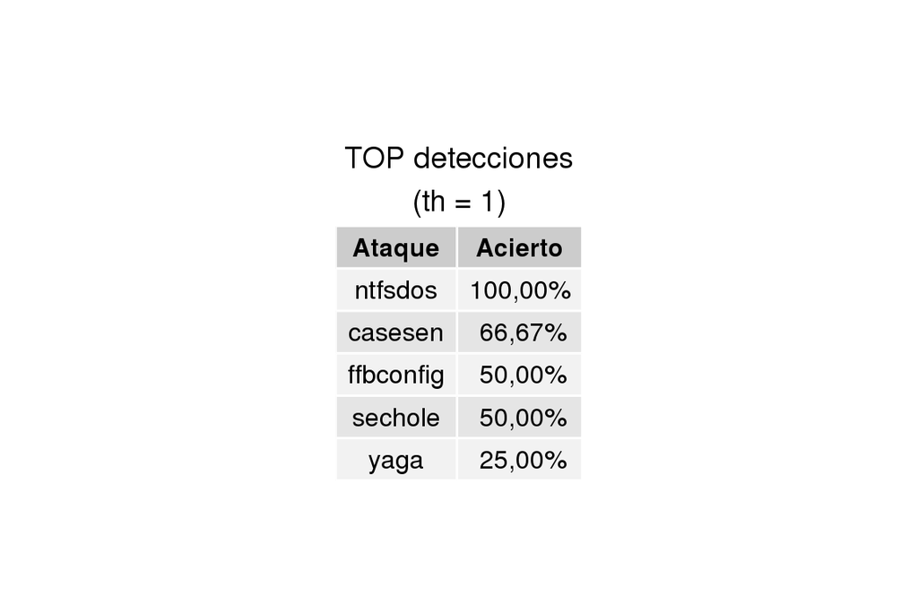

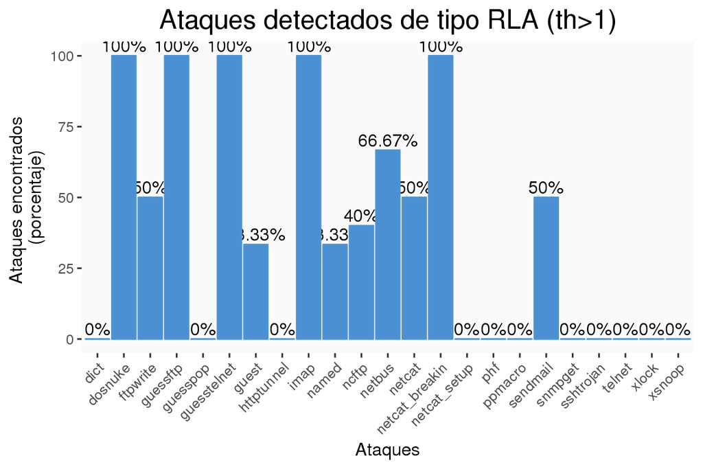

[figure not shown]

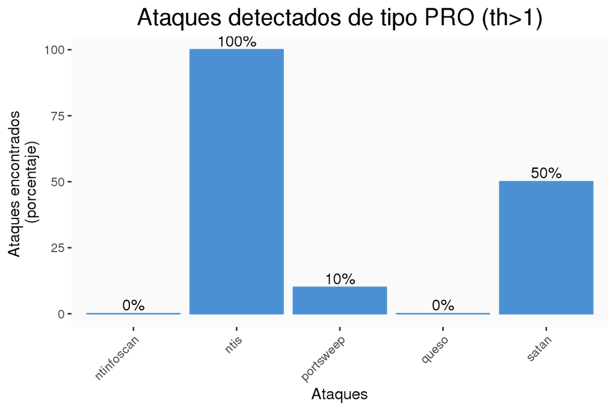

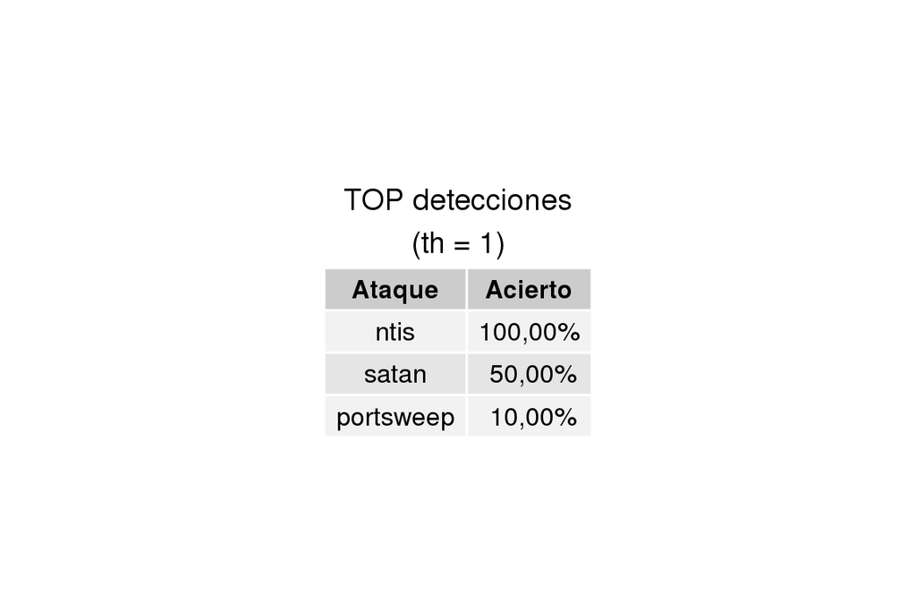

# Analysis with other thresholds

In the next sections we show the same results, but using greater threshold, so the system is less restrictive about waht they consider as an anomaly or an attack.

### False Positives/Negatvives and true detections

Render by package table False Positive/Negative and correct detections with threshold 1 and compare with threshold 20 and 37

- Render by packet, False Positive/Negative and correct detections with threshold 1

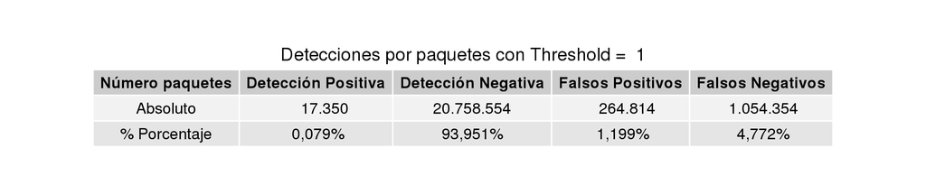

- Render by packet, False Positive/Negative and correct detections comparison between threshold 1 and threshold 20

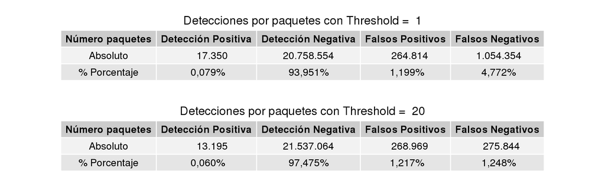

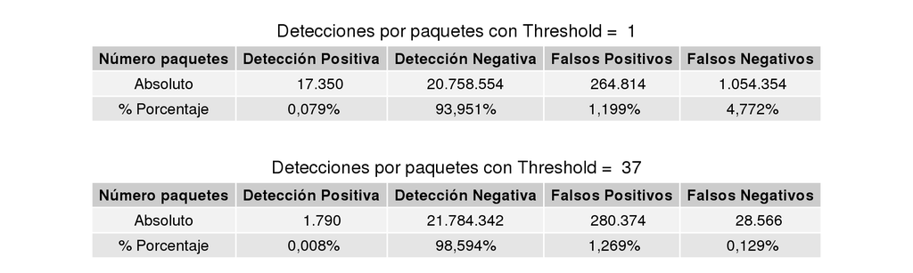

### False Positives/Negatives and true detections (based on number of attacks)

Render by number of attacks table False Positive/Negative and correct detections with threshold 1 and compare with threshold 20 and 37

- Render by attack, False Positive/Negative and correct detections with threshold 1

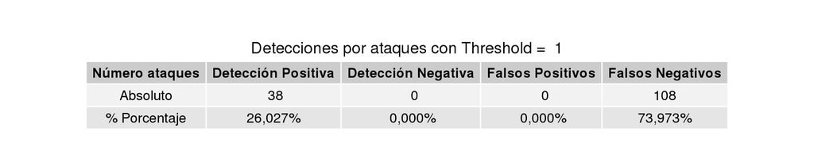

- Render by attack, False Positive/Negative and correct detections comparison between threshold 1 and threshold 20

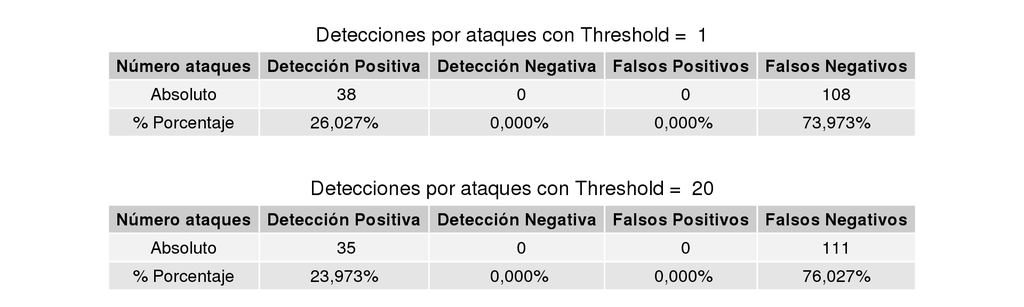

- Render by attack, False Positive/Negative and correct detections comparison between threshold 1 and threshold 37

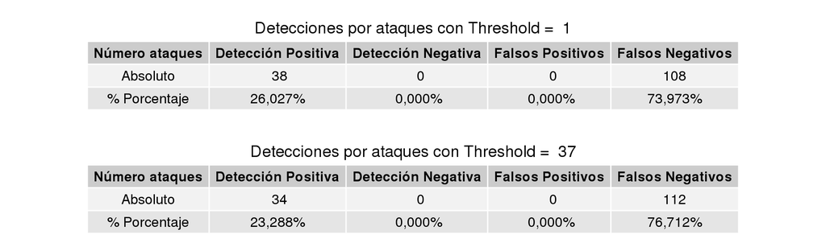